# ¶ AFD : Analyse factorielle discriminante : Partie II ¶

EP - FOUILLE DE DONNEES AVEC R - Bertrand Roudier - ESIEE Paris

```r
print(B)
```

```
##                 TP     Soleil    Chaleur      Pluie
## TP      12354.9238 10646.0470  766.80455 -5522.7217
## Soleil  10646.0470  9614.9726  641.52122 -5173.7007
## Chaleur   766.8046   641.5212   48.42853  -324.7011
## Pluie   -5522.7217 -5173.7007 -324.70111  2858.5638
```

```r
print(W)
```

```
##                TP    Soleil   Chaleur      Pluie
## TP      6991.8271 1714.2558 420.61586  392.27362
## Soleil  1714.2558 5946.8344 154.27117 -144.05971
## Chaleur  420.6159  154.2712  48.95209  -31.75045
## Pluie    392.2736 -144.0597 -31.75045 5249.97683
```

```r
print(B + W)
```

```
##                TP     Soleil    Chaleur      Pluie
## TP      19346.751 12360.3028 1187.42042 -5130.4481
## Soleil  12360.303 15561.8071  795.79239 -5317.7604
## Chaleur  1187.420   795.7924   97.38062  -356.4516
## Pluie   -5130.448 -5317.7604 -356.45156  8108.5407
```

```r
print(VecP)
```

```
##               [,1]         [,2]
## [1,] -0.0079538858 -0.010446557
## [2,] -0.0071030886  0.002904653
## [3,] -0.0004827976 -0.001166821
## [4,]  0.0037897658 -0.006519668
```

```r
print(ValP)
```

```
## [1] 50.822338  2.147897
```

```r
print(result)
```

```
##    valeur propres  % inertie correlation     Wilks   Kh Deux      p.value
## u1      50.822338  95.945086   0.9903047 0.0192967 116.46073 0.000000e+00
## u2       2.147897   4.054914   0.8260313 0.3176724  33.82867 4.363534e-05
```

#### 1. Introduction

Dans la première partie, nous avons effectué :

- le calcul des vecteurs directeurs des axes factoriels sur lequels la projection des centres de gravité de chaque classe est optimale. Sachant que nous avons, dans notre exemple 3 classes, le nombre d’axes max sera de k-1 = 2 axes.
- le calcul des valeurs propres de chaque axe qui permet de calculer l’inertie c.a.d, la part d’information (en terme de dispertion - variance) qu’apporte chaque axe. Les valeurs calculées sont parlantes: le premier axes explique à lui seul 95% de la dispersion initiale du nuage de point et le second axes 5%.
- la construction du test statistique permettant de valider le caractère discriminant des axes factoriels

La seconde étape du travail va consister à utiliser les coordonnées des observations dans le plan factoriel pour réaliser un classifieur et de tester sa qualité.

- Nous allons donc devoir calculer les coordonnées des observations sur chaque axe factoriel et réaliser un grahique 2D (x = factoriel 1, y = axes factoriel 2) puis positionner les différentes observations dans le plan.
- A partir des coordonnées dans le plan factoriel et de la classification (bas-good-medium) initiale :
  - Nous calculons les coordonnées des centres de gravité de chaque classe dans le plan factoriel,
  - Pour chaque observation, nous calculons les distances Euclidiennes avec les centres de gravité de chaque classe,
  - Pour chaque observation, le critère d’affectation sera le minimum des distances.
- Une fois la classification réalisée dans le plan factoriel, nous comparons cette dernière à celle observée (gold standard) à l’aide d’une matrice des confusions. Cette dernière nous permettra de valider la qualité prédictive de l’AFD.

*remarque : Les graphiques sont réalisées à l’aide de la librairie **ggplot2**. Les scripts sont fournies. Il suffira donc de les utiliser et de les copier dans votre code et éventuellement les modifier si nécessaire*

#### 2. Calcul des coordonnées des individus dans le plan factoriel

le calcul des coordonnées des individus sur les axes (appelées scores en anglais) s’effectue en réalisant la projection des observations X **(centrées)** sur les axes factoriels tel que : $Score{s_{i,j}} = {Z_{i,j}}{U_j}$ avec ${Z_{i,j}} = {X_{i,j}} - {m_j}$ matrice des observations centrées , $U$ matrice des vecteurs propres. *i* et *j* correspondent respectivement aux lignes (observations) et aux colonnes(variables)

- Les coordonnés des 10 premiers individus (lignes) sont les suivants :

| Axe_1 | Axe_2 |
| --- | --- |
| 1.0821474 | 0.8528457 |
| 2.5548058 | 1.2403222 |
| 0.9582812 | -0.5144382 |
| 2.9605413 | -0.7215907 |
| -1.0288490 | -0.4659355 |
| -2.3740409 | 0.1270597 |
| 2.8348896 | -0.3654946 |
| 2.3635689 | 0.9278486 |
| 3.1806860 | -1.2250821 |
| -1.4714248 | -1.9364403 |

- Si l’on rajoute à *Score* la variable factorielle relative aux (groupes-classes) nous obtenons le dataframe suivant (10 premières lignes) :

| Axe_1 | Axe_2 | Qualite |
| --- | --- | --- |
| 1.0821474 | 0.8528457 | moyen |
| 2.5548058 | 1.2403222 | mauvais |
| 0.9582812 | -0.5144382 | moyen |
| 2.9605413 | -0.7215907 | mauvais |
| -1.0288490 | -0.4659355 | bon |
| -2.3740409 | 0.1270597 | bon |
| 2.8348896 | -0.3654946 | mauvais |
| 2.3635689 | 0.9278486 | mauvais |
| 3.1806860 | -1.2250821 | mauvais |
| -1.4714248 | -1.9364403 | moyen |

- Représentation des individus dans la plan factoriel.
  - le script suivant permet de représenter les individus dans le plan factoriel. De plus, chaque couleur représente le groupe d’appartenance des différents individus(Bad, Good, Medium). La variable *Qualite* (son nom) est remplacé par *‘class’* qui est plus générique si l’on désire intégrere ce code dans une fonction.

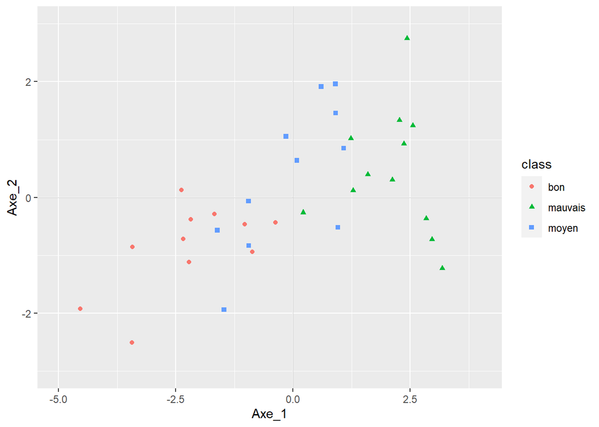

```r
# equivalent de ggplot en python : plotnine

library(ggplot2)
names(Scores)[3] <- 'class' <- 'class'

gr_ind <- ggplot() +  geom_point(data = Scores  ,aes( x = Axe_1, y = Axe_2, colour = class, shape = class))                                # trace les points
gr_ind <- gr_ind   +  geom_hline(yintercept = 0 , size = 0.1, colour = '#CCCCCC') + geom_vline(xintercept  = 0, size = 0.1,colour = '#CCCCCC') # trace les lignes
gr_ind <- gr_ind   +  xlim(c(-5,4)) + ylim(c(-3,3))  # uniformités des échelles
gr_ind
```

#### 3. Classification

##### 3.1 Calcul des centres de gravité

Nous allons voir maintenant si la représention dans le plan factoriel permet de retrouver de convenable les groupes d’appartenances des différents individus.

- Nous calculons les centres de gravité de chaque classe dans le plan factoriel

| Group.1 | Axe_1 | Axe_2 |
| --- | --- | --- |
| bon | -2.22198634 | -0.8631555 |
| mauvais | 2.08577435 | 0.4603207 |
| moyen | -0.05340387 | 0.3609875 |

- La position des centres de gravité dans le plan factoriel est le suivant :

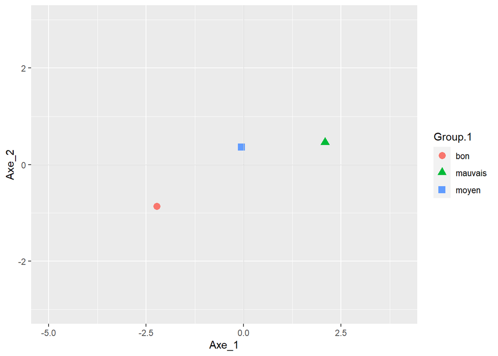

```r
 gr_ind <- ggplot() +  geom_point(data = G_fac  ,aes( x = Axe_1, y = Axe_2, colour = Group.1, shape =  Group.1), size = 3)  +  # trace les centres de gravité
                       geom_hline(yintercept = 0 , size = 0.1, colour = '#CCCCCC') + geom_vline(xintercept  = 0, size = 0.1,colour = '#CCCCCC') + # trace les lignes
                       xlim(c(-5,4)) + ylim(c(-3,3))
 gr_ind
```

##### 3.2 Calcul des distances ente les individus et les centres de gravité

- Pour chaque observation, nous calculons leur distance par rapport au centre de gravité de chaque classe (dans le plan composé des axes factoriels 1 et 2).
- Le tableau suivant résume les distances de chaque observation (lignes) par rapport à chaque centre de gravité

| bad | good | medium |
| --- | --- | --- |
| 3.723165 | 1.077656 | 1.237498 |
| 5.219422 | 0.910161 | 2.752451 |
| 3.199329 | 1.490435 | 1.337863 |
| 5.184461 | 1.470419 | 3.202474 |
| 1.257522 | 3.249435 | 1.278786 |
| 1.001822 | 4.472249 | 2.332398 |
| 5.081305 | 1.114964 | 2.978257 |
| 4.922907 | 0.543831 | 2.482557 |
| 5.414782 | 2.009829 | 3.602076 |
| 1.309688 | 4.289304 | 2.699807 |

- Chaque observation sera affectée au groupe dont la distance avec son centre de gravité est minimale. La prédiction d’appartenance de chaque observation au groupe selon l’AFD (projection dans le plan factoriel) est la suivante :
- Le tableau suivant compare les affectations liées à la prédiction et l’appartenance au groupe (gold standard)

| Qualite | Qualite_pred |
| --- | --- |
| moyen | good |
| mauvais | good |
| moyen | medium |
| mauvais | good |
| bon | bad |
| bon | bad |
| mauvais | good |
| mauvais | good |
| mauvais | good |
| moyen | bad |
| bon | bad |
| mauvais | medium |
| mauvais | good |
| bon | bad |
| moyen | medium |
| moyen | medium |
| moyen | medium |
| mauvais | good |
| moyen | bad |
| bon | bad |
| moyen | medium |
| bon | bad |
| moyen | medium |
| bon | bad |
| moyen | medium |
| bon | bad |
| moyen | bad |
| mauvais | good |
| bon | bad |
| bon | medium |
| mauvais | good |
| bon | bad |
| mauvais | good |
| mauvais | good |

#### 3. Qualité de la prédiction

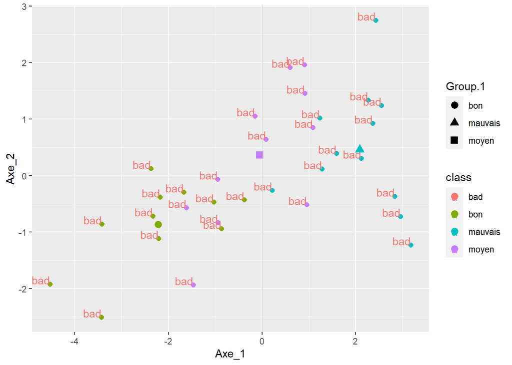

```r
Scores <- cbind(Scores, good_class = ifelse(comp$Qualite_pred ==  comp$Qualite, 'good','bad') )

gr_ind <- ggplot() + geom_point(data = Scores, aes(x = Axe_1, y = Axe_2, colour = class), size = 2)    +
                     geom_text (data = Scores, aes(x = Axe_1, y = Axe_2, label = good_class, colour = good_class), hjust = 1, vjust = 0 ) +
                     geom_point(data = G_fac,  aes(x = Axe_1, y = Axe_2, colour = Group.1, shape =  Group.1), size = 3)  +  # trace les centres de gravité
                     geom_hline(yintercept = 0 , size = 0.1, colour = '#CCCCCC') + geom_vline(xintercept  = 0, size = 0.1,colour = '#CCCCCC')
gr_ind
```